# Visualización básica

09/2018

## Leemos datos

Leemos el conjunto de datos que creamos en el tema anterior como combinación de `core_dataset.csv` y `production_staff.csv`

```r
library(here)
load(here("data","join_dataset_clean.RData"))
```

## Resumen

Vamos a ver el resumen de la variable `PayRate`.

```r
summary(df$PayRate)
```

```
##    Min. 1st Qu.  Median    Mean 3rd Qu.    Max.
##    14.0    18.0    22.0    23.2    24.5    80.0
```

## Histogramas

Los histogramas nos permiten visualizar la forma que tiene la distribución de una variable empleando la función `hist()`.

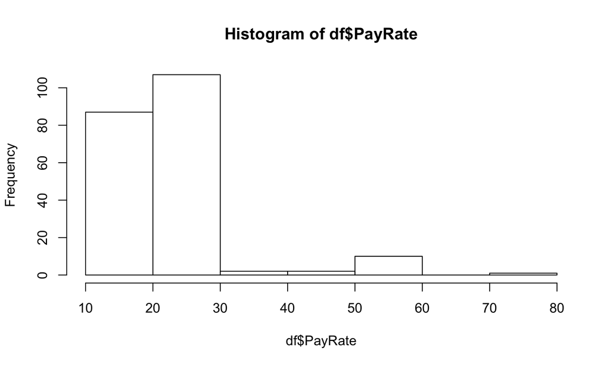

Es importante tener en cuenta que la elección de los puntos de corte de las barras pueden cambiar el histograma.

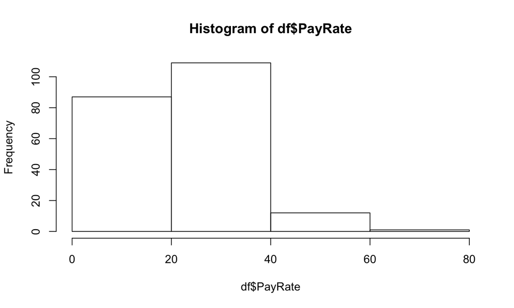

```r
hist(df$PayRate, breaks = 3)
```

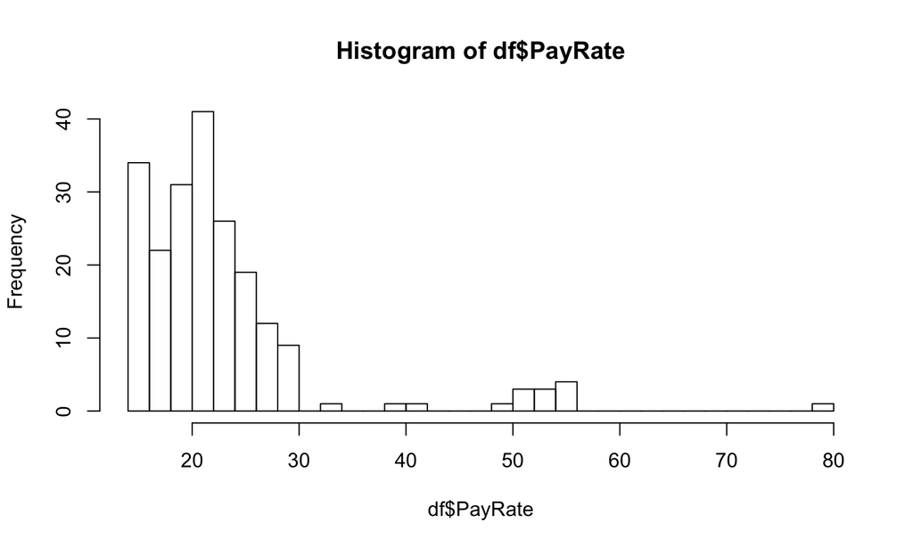

```r
hist(df$PayRate, breaks = 30)
```

## Personalizando la gráfica

Es posible personalizar la gráfica incluyendo distintos parámetros como el título de la gráfica `main`, la etiquetas de los ejes (`xlab`, `ylab`), o subtítulo (`sub`).

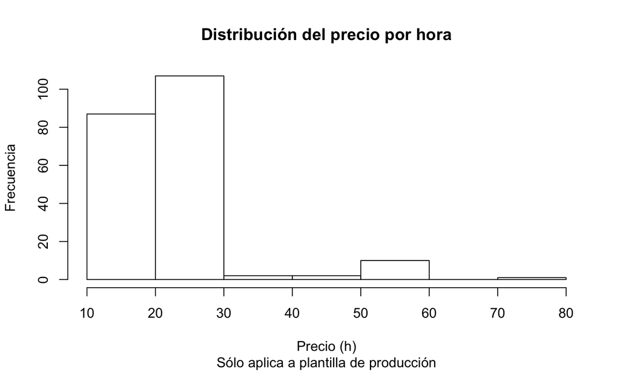

```r
hist(df$PayRate,
     main="Distribución del precio por hora",
     sub="Sólo aplica a plantilla de producción",
     xlab="Precio (h)", ylab="Frecuencia")
```

Los colores y bordes de las barras también se pueden modificar con los parámetros `col` y `border` respectivamente.

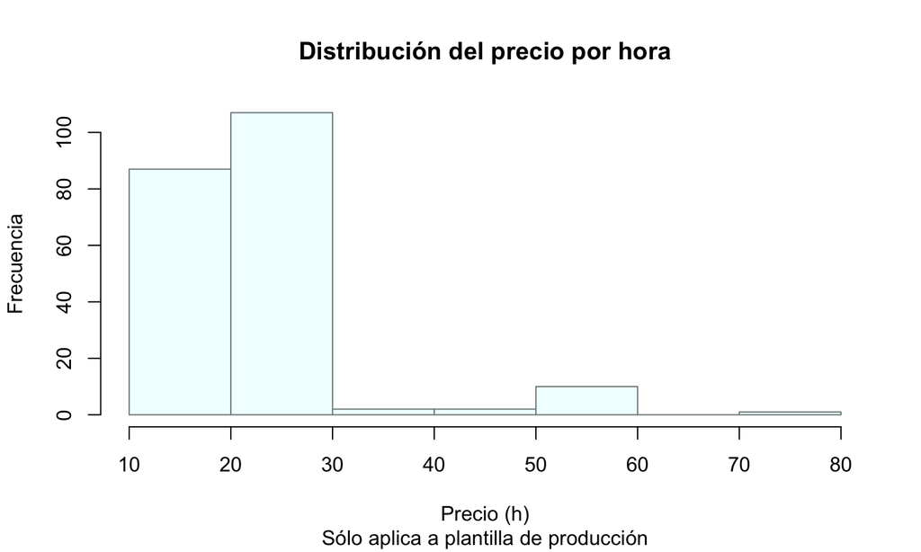

```r
hist(df$PayRate,
     main="Distribución del precio por hora",
     sub="Sólo aplica a plantilla de producción",
     xlab="Precio (h)", ylab="Frecuencia",
     col="azure", border="azure4")
```

## Parámetros para definir colores

- `col` color por defecto
- `col.axis` color para los ejes
- `col.lab` color para el título de los ejes
- `col.main` color para el título principal
- `col.sub` color para el subtítulo
- `fg` color para los elementos visibles
- `bg` color para el fondo

## Función de densidad

La función de densidad es una aproximación que muestra de manera continua la distribución de una variable.

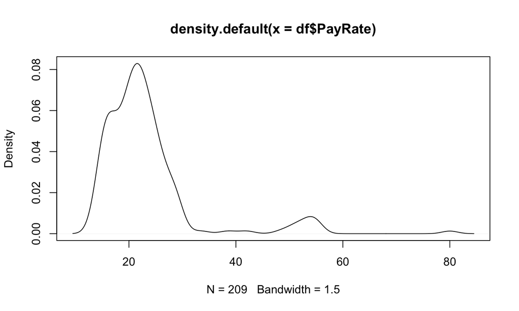

```r
plot(density(df$PayRate))
```

## Boxplots

Los diagramas de caja resumen la distribución de una o más variables, y permiten compararlas fácilmente en una sola gráfica.

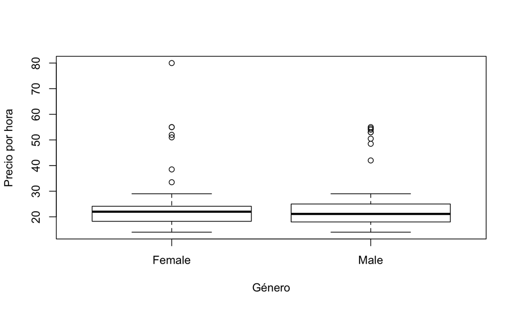

```r
boxplot(PayRate ~ Sex, data=df,
        xlab="Género", ylab="Precio por hora")
```

## Gráficos de barras

Los gráficos de barras permiten visualizar variables categóricas.

Aunque no se muestra en el gráfico, siguen siendo aplicables los parámetros para modificar el color de las barras

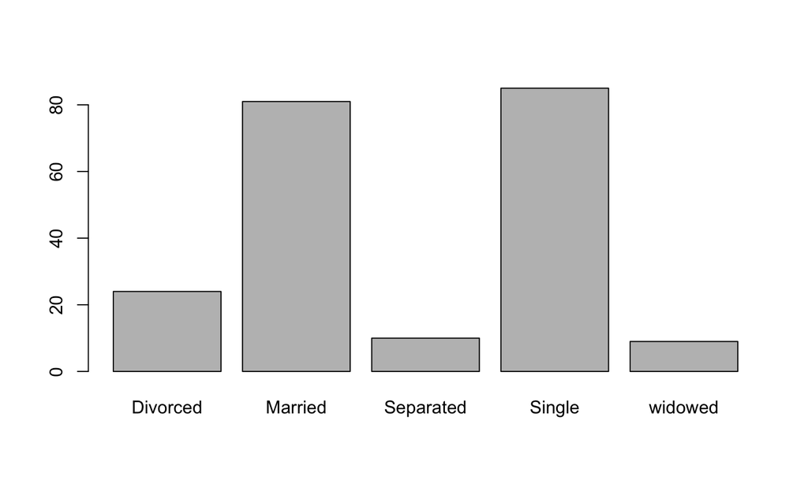

```r
count <- table(df$MaritalDesc)
barplot(count)
```

Se puede mostrar el cruce de dos variables categóricas agrupando las barras por colores.

Primero se genera una tabla con las combinaciones, y luego se indican los colores a emplear. Opcionalmente se puede incluir leyenda (`legend`).

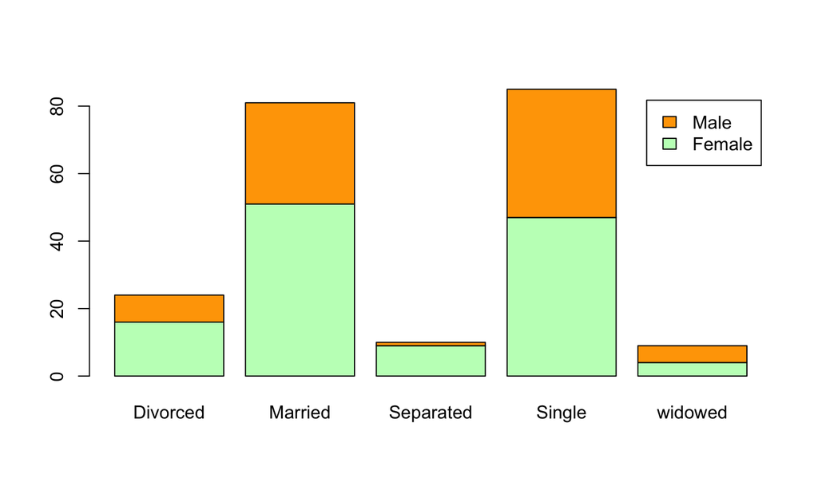

```r
count <- table(df$Sex, df$MaritalDesc)
barplot(count, col=c("darkseagreen1", "orange"),
        legend = rownames(count))
```

El párametro `beside` permite controlar la posición de las barras.

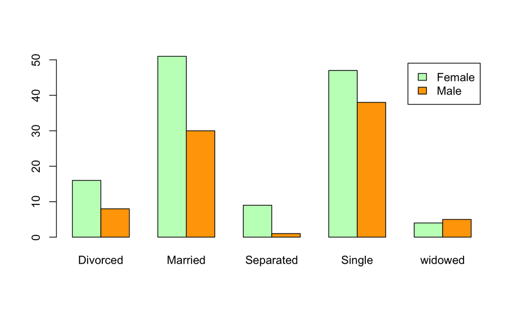

```r
barplot(count,
        col=c("darkseagreen1", "orange"),
        legend = rownames(count),
        beside=TRUE)
```

Mientras que el parámetro `horiz` nos permite girar las barras en posición horizontal.

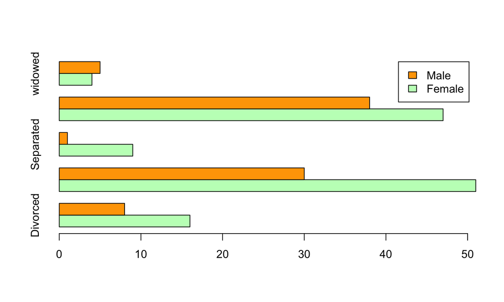

```r
barplot(count,
        col=c("darkseagreen1", "orange"),
        legend = rownames(count),
        beside=TRUE, horiz=TRUE)
```

## Función `plot`

La función genérica `plot()` permite visualizar dos variables escogiendo una representación adecuada.

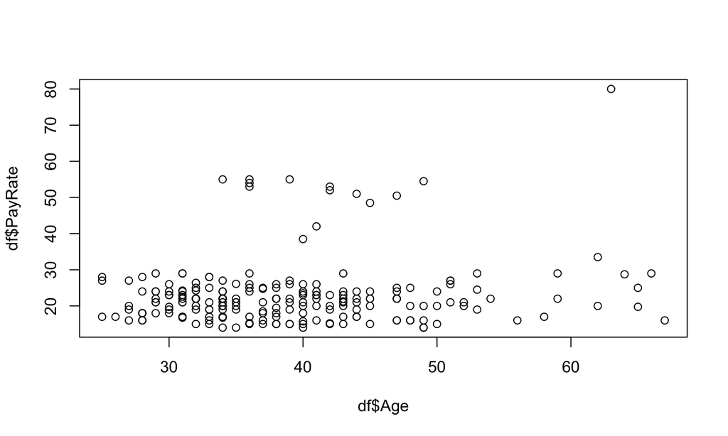

```r
plot(df$Age, df$PayRate)
```

Se puede modificar el símbolo para representar un punto con el parámetro `pch`.

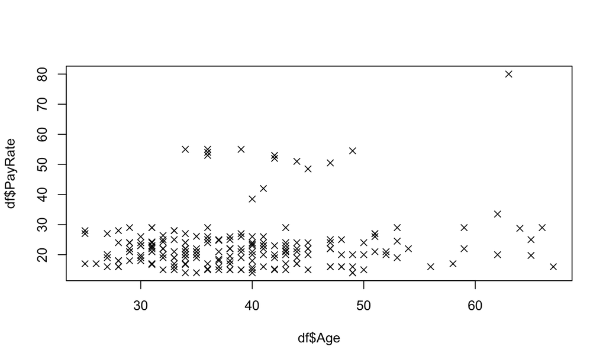

```r
plot(df$Age, df$PayRate, pch=4)
```

## Lista de símbolos disponibles

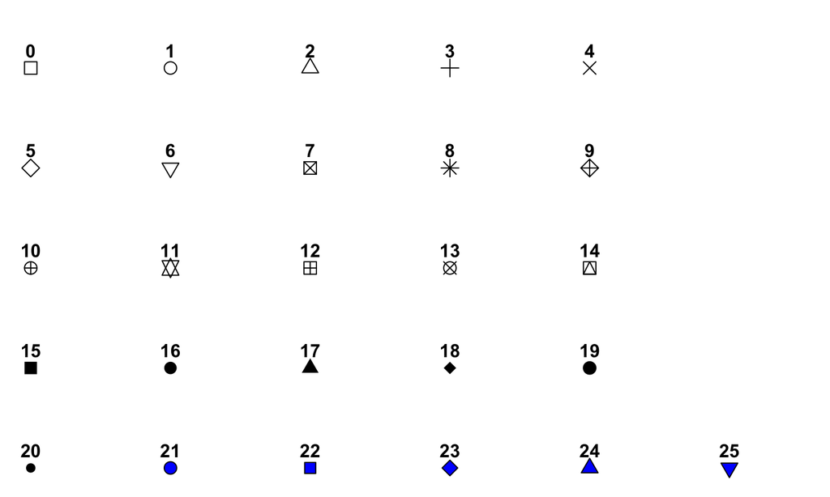

De nuevo es posible agrupar la gráfica por una variable adicional, y colorear los puntos. Así, como añadir los parámetros de personalización anteriormente visto.

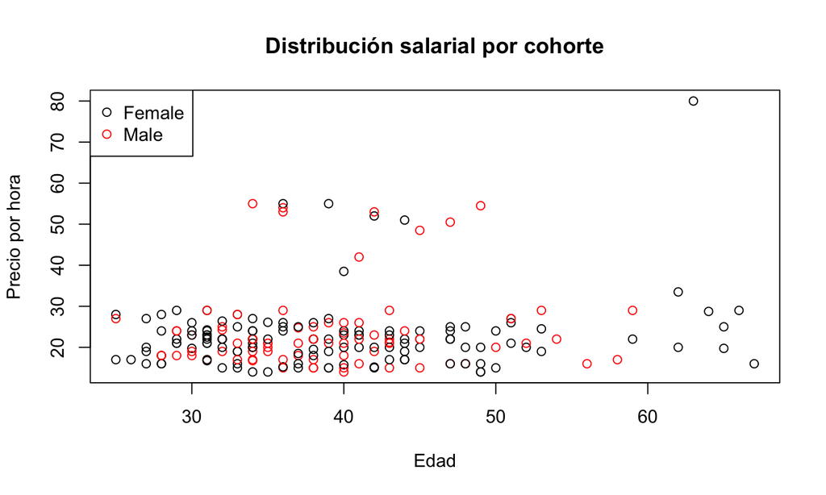

```r
plot(df$Age, df$PayRate, col=df$Sex,
     main="Distribución salarial por cohorte",
     xlab="Edad", ylab="Precio por hora")
legend("topleft",
       levels(df$Sex),
       col=1:length(levels(df$Sex)),
       pch = 1)
```

## Series temporales

Cuando el eje `x` se corresponde con una medida del tiempo, tenemos una serie temporal de una variable.

Primeramente, añadimos una variable que especifique el eje y la escala del tiempo.

```r
library(tidyverse)
hiring <- df %>%
            mutate(year = format(DateofHire, "%Y")) %>%
            group_by(year) %>%
            summarise(total = n())
hiring
```

```
## # A tibble: 10 x 2
##    year  total
##    <chr> <int>
##  1 2007      2
##  2 2008      2
##  3 2009      5
##  4 2010      6
##  5 2011     70
##  6 2012     34
##  7 2013     37
##  8 2014     35
##  9 2015     11
## 10 2016      7
```

La serie temporal se visualiza indicándolo el parámetro `type`.

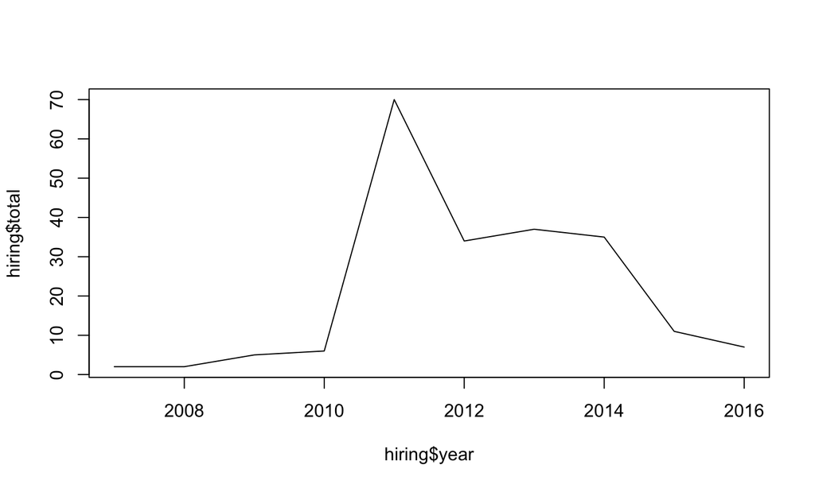

```r
plot(hiring$year, hiring$total, type="l")
```

Los parámetros `lty` y `lwd` permiten cambiar el tipo de línea y el ancho respectivamente.

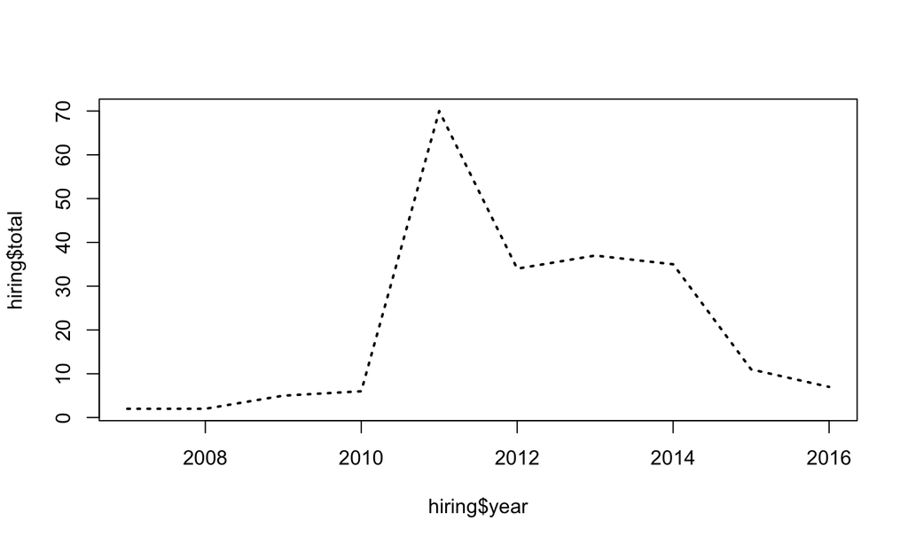

```r
plot(hiring$year, hiring$total, type="l",
     lty=3, lwd=2)
```

Es posible superponer varias visualizaciones en un mismo gráfico.

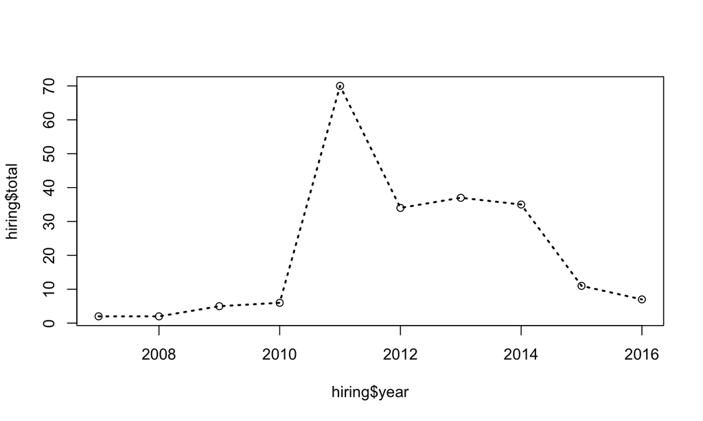

```r
plot(hiring$year, hiring$total)
lines(hiring$year, hiring$total,
     lty=3, lwd=2)
```

Así como incluir etiquetas para cada uno de los puntos.

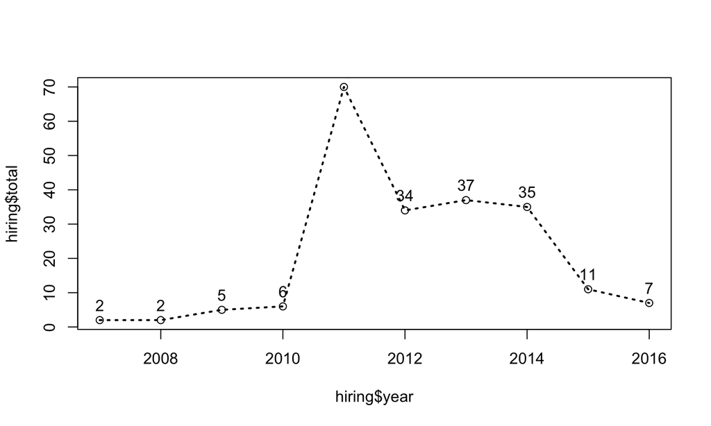

```r
plot(hiring$year, hiring$total)
lines(hiring$year, hiring$total,
     lty=3, lwd=2)
text(hiring$year, hiring$total, labels=hiring$total, pos=3)
```

## Exportar una imagen

Es posible exportar una imagen a distintos formatos (png, jpg, tiff, bmp, pdf…)

```r
png(file = here("img","myplot.png"), bg = "transparent")
plot(hiring$year, hiring$total)
lines(hiring$year, hiring$total,
     lty=3, lwd=2)
text(hiring$year, hiring$total, labels=hiring$total, pos=3)
dev.off()
```

## Configuración por defecto

La función `par()` permite modificar la configuración que se aplica por defecto a cada gráfica.

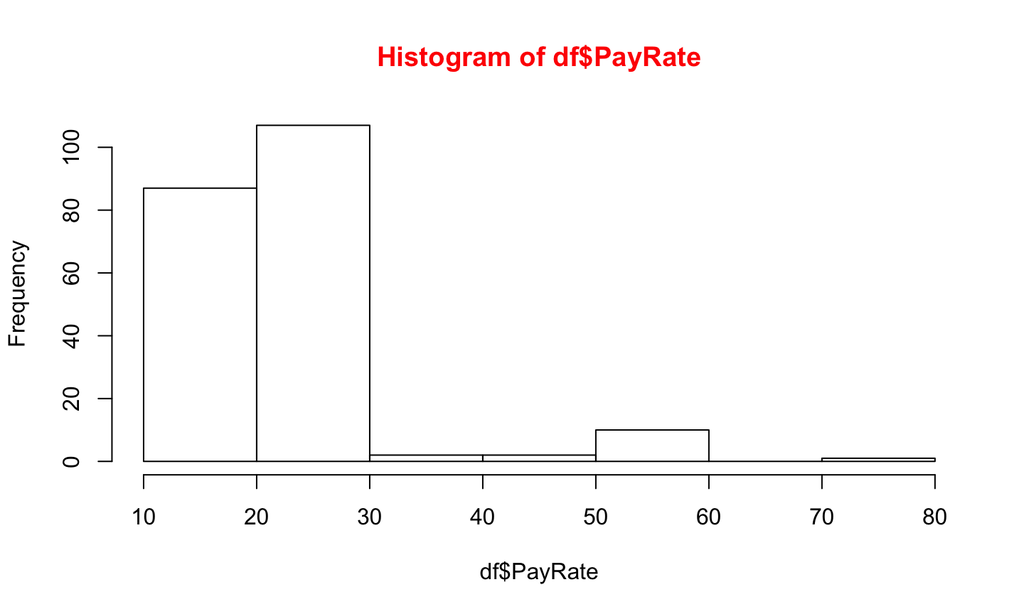

```r
old_par <- par()
par(col.main="red")
hist(df$PayRate)
```

```r
par(old_par)
```

## Recursos y material

- [Colores en R](http://www.stat.columbia.edu/~tzheng/files/Rcolor.pdf)
- [Párametros gráficos](https://www.statmethods.net/advgraphs/parameters.html)
- [Gráficas más habituales](https://www.statmethods.net/graphs/creating.html)